# Phloem Temp

Zjrobbin

8/11/2020

### Data

Here is the data from Jim Powell It is four trees North South,a bark surface temperature, and the ambient air. Measured every hour for ~ 1 year

I started by reducing North South to a single tree, and toook the mean of all trees.

```r
PonderosaTrunc<-data.frame(Tree1=(PonderosaData$T1N+PonderosaData$T1S)/2,
                           Tree2=(PonderosaData$T2N+PonderosaData$T2S)/2,
                           Tree3=(PonderosaData$T3N+PonderosaData$T3S)/2,
                           Tree4=(PonderosaData$T4N+PonderosaData$T4S)/2,
                           AirTemp=PonderosaData$Air)


PonderosaTrunc$meanT<-(PonderosaTrunc$Tree1+PonderosaTrunc$Tree2+PonderosaTrunc$Tree3+PonderosaTrunc$Tree4)/4
```

Here I clean up the date structure

```r
PonderosaTrunc$Day<-PonderosaData$JD
PonderosaTrunc$Year<-PonderosaData$Year
PonderosaTrunc$Hour<-PonderosaData$Time

###Missing Data
PonderosaTrunc<-PonderosaTrunc[c(-8073),]
PonderosaTrunc$Day[PonderosaTrunc$Year=="1995"]<-PonderosaTrunc$Day[PonderosaTrunc$Year=="1995"]+365
PonderosaTrunc$Date<-as.Date(PonderosaTrunc$Day-1,origin = "1994-01-01")
```

```r
DayAir<-PonderosaTrunc %>%
  group_by(Date=Date) %>%
  summarise(Max=max(AirTemp),Min=min(AirTemp))
```

I wanted to look at the best way to orient the sin wave So I looked at the best combination of a times to capture the min and max I decided on 4 am 4 pm to be the apex and low

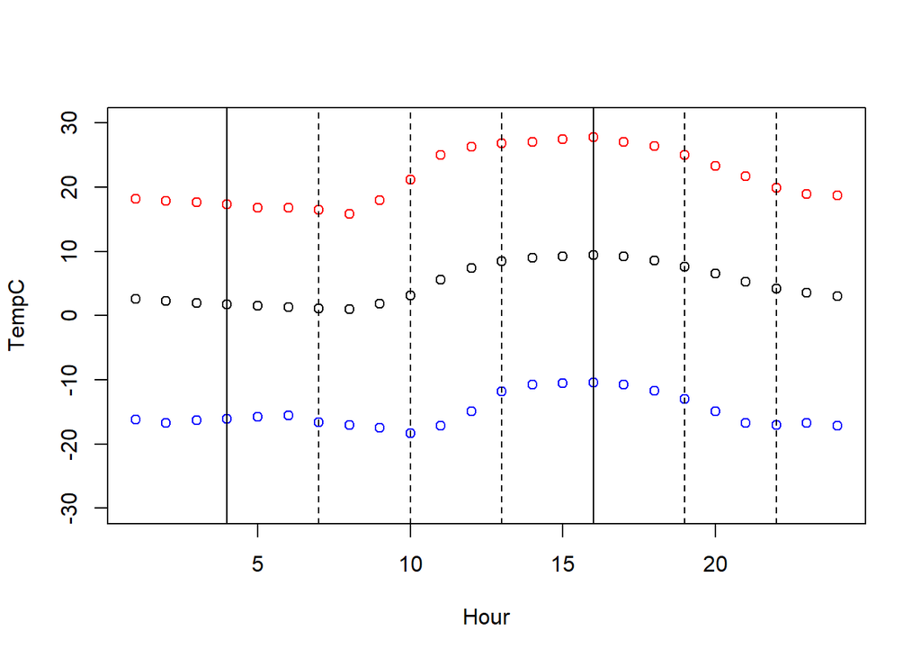

```r
DayAir<-PonderosaTrunc %>%
  group_by(Date=Date) %>%
  summarise(Max=max(AirTemp),Min=min(AirTemp))

HourlyAir<-PonderosaTrunc %>%
  group_by(Date=Hour) %>%
  summarise(Max=max(AirTemp),Min=min(AirTemp),Mean=mean(AirTemp))

plot(HourlyAir$Max,col="red",ylim=c(-30,30),xlab="Hour",ylab="TempC")
points(HourlyAir$Min,col="blue")
points(HourlyAir$Mean)
abline(v=4)
abline(v=7,lty=2)
abline(v=10,lty=2)
abline(v=13,lty=2)
abline(v=16)
abline(v=19,lty=2)
abline(v=22,lty=2)
```

This is the max mean and min.

This function sin-adjust the minimum and maximum into 8 segments  
It this one returns a data frame with each hours

```r
Tmax<-DayAir$Max
Tmin<-DayAir$Min
vector<-NULL
for(i in 1:length(Tmax)-1){
  Min<-Tmin[i]
  Max<-Tmax[i]
  Min2<-Tmin[i+1]
  Mean=(Max+Min)/2
  Mean2=(Max+Min2)/2
  Dif=(Max-Min)
  Dif2=(Max-Min2)
  Fouram<-Min
  Sevenam<-Mean+(.5*Dif*sin(-pi/4))
  Tenam<-Mean+(.5*Dif*sin(0))
  Onepm<-Mean+(.5*Dif*sin(pi/4))
  Fourpm<-Mean+(.5*Dif*sin(pi/2))
  Sevenpm<-Mean2+(.5*Dif2*sin(pi/4))
  Tenpm<-Mean2+(.5*Dif2*sin(0))
  OneAm<-Mean2+(.5*Dif2*sin(-pi/4))


  if(i==1){vector<-cbind(Fouram,Sevenam,Tenam,Onepm,Fourpm,Sevenpm,Tenpm,OneAm)}
  else{vector<-rbind(vector,cbind(Fouram,Sevenam,Tenam,Onepm,Fourpm,Sevenpm,Tenpm,OneAm))}
}
SimData<-as.data.frame(vector)
```

I then fit a linear phloem adjustment to each hour, to account for the buffering of the bark

```r
#### Four Am
par(pty="s")
FourAMphl<-PonderosaTrunc$meanT[PonderosaTrunc$Hour=="400"]
lm1<-lm(FourAMphl~SimData$Fouram[1:386])
plot(FourAMphl,3.8532+(.9677*SimData$Fouram[1:386]),xlim=c(-15,25),ylim=c(-15,25),ylab=c("Modeled Response"),xlab=c("Obsevered Phloem Temps"))
abline(1,1)
summary(lm1)
```

```
##
## Call:
## lm(formula = FourAMphl ~ SimData$Fouram[1:386])
##
## Residuals:
##     Min      1Q  Median      3Q     Max
## -5.2429 -1.5456 -0.2583  1.4053  7.7769
##
## Coefficients:
##                       Estimate Std. Error t value Pr(>|t|)
## (Intercept)            3.85319    0.10539   36.56   <2e-16 ***
## SimData$Fouram[1:386]  0.96767    0.01325   73.02   <2e-16 ***
## ---
## Signif. codes:  0 '***' 0.001 '**' 0.01 '*' 0.05 '.' 0.1 ' ' 1
##
## Residual standard error: 2.069 on 384 degrees of freedom
## Multiple R-squared:  0.9328, Adjusted R-squared:  0.9326
## F-statistic:  5332 on 1 and 384 DF,  p-value: < 2.2e-16
```

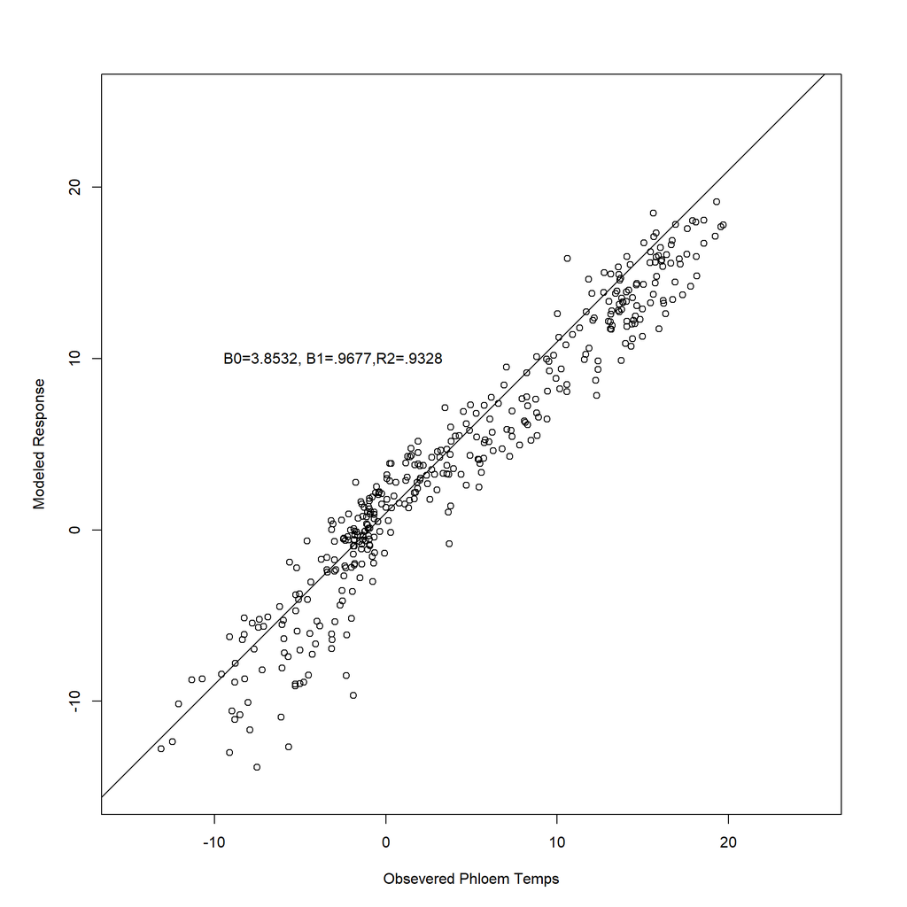

```r
text(-10, 10, "B0=3.8532, B1=.9677,R2=.9328", pos = 4)
```